# My document

Leo Zhou

2021-08-05

```
## [1] "Last run on"
```

```
## [1] "2021-08-05"
```

```r
library(ggplot2)
library(dplyr)
library(lme4)
library(MASS)
library(geepack)
library(glmmLasso)
library(car)
library(MuMIn)
library(afex)
library(blme)
library(magrittr)
library(ggeffects)
library(sjmisc)
library(splines)
```

## Functions

```r
lrAcc <- function(lrMod, responseVar, use.ranef=TRUE){
    ## convert response variable into a factor if it's not one
  if(!is.factor(model.frame(lrMod)[,responseVar])){
    model.frame(lrMod)[,responseVar] <- as.factor(model.frame(lrMod)[,responseVar])
  }

    ## model predictions in log-odds
  if(use.ranef){
    preds = predict(lrMod, newdata=model.frame(lrMod))
  } else{
    ## predict for average participant/item/other
        preds = predict(lrMod, newdata=model.frame(lrMod), re.form=NA)
  }
    ## transform to 0/1 prediction
    preds <- ((sign(preds)/2)+0.5)

    ## response variable values, transformed to 0/1
    respVarValues <- model.frame(lrMod)[,responseVar]
    ## if the response is already 0/1, just use it
    if(is.numeric(respVarValues)){
        y <- respVarValues
    } else{
        ## otherwise, transform to 0/1
        y <- (as.numeric(model.frame(lrMod)[,responseVar])-1)
    }

    ## how often is prediction the same as the actual response
    acc <- sum(preds==y)/length(preds)

    return(acc)

}

baselineAcc <- function(lrMod, responseVar){
    response <- model.frame(lrMod)[,responseVar]
    tab <- table(response)
    return(max(tab)/sum(tab))
}
```

## Overuse EBM

### Data cleaning

```r
over.df <- read.csv("C:/Users/leo.zhou/Desktop/Equity OKR/R/data/overuse_df.csv",
                    na.strings=c("","NA"))
```

```r
summary(over.df)
```

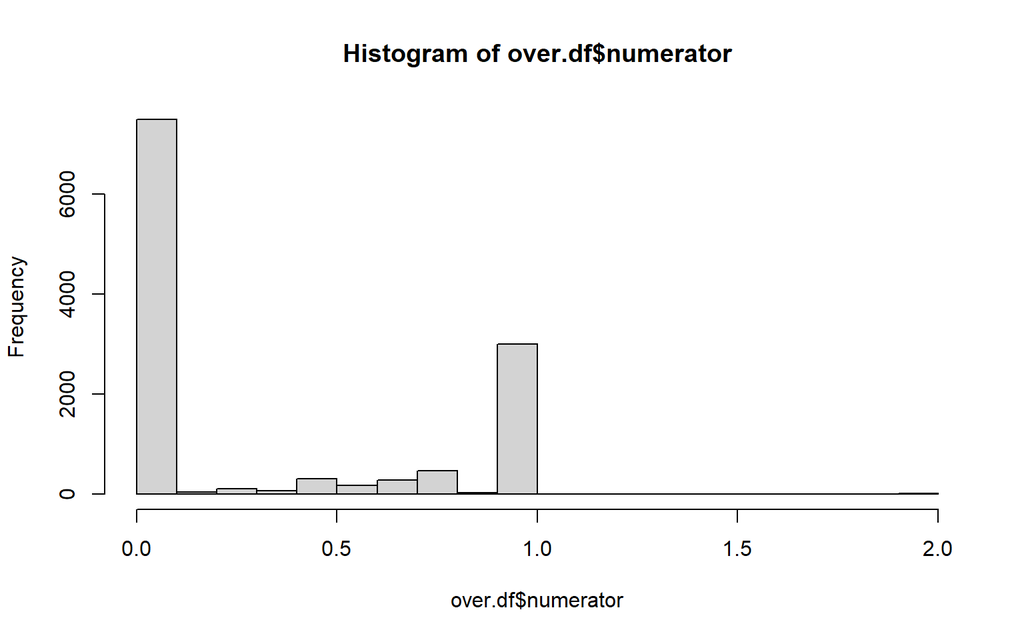

```r
hist(over.df$numerator)
```

```r
#there are some numerators = 2, and the denominator = 2, for regression purpose, change those to 1
#over.df[over.df$numerator==2,]
```

```r
#for regression purpose, set the denominator == 2 to 1
over.df$numerator[over.df$numerator == 2 ] <- 1
```

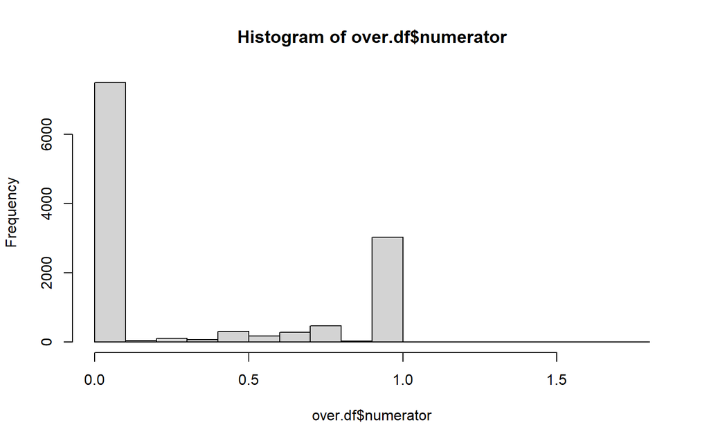

```r
hist(over.df$numerator)
```

```r
#explore numerator > 1
#over.df[over.df$numerator > 1,]
```

```r
#explore numerator > 1
#over.df[over.df$numerator > 0 & over.df$numerator < 1 ,]
```

```r
over.df$ci_measure_cat <- as.factor(over.df$ci_measure_cat)
levels(over.df$ci_measure_cat)
```

```
## [1] "NYU"                     "Overuse/Appropriateness"
## [3] "Respiratory Conditions"  "Utilization"
```

```r
#for regression purpose, remove all the NYU measures
over.df <- over.df[over.df$ci_measure_cat != "NYU",]
summary(over.df)
```

```r
#change the numerator to factor 0 and 1
over.df$numerator <- as.factor(over.df$numerator)
levels(over.df$numerator)
```

```
## [1] "0" "1"
```

```r
summary(over.df$numerator)
```

```
##    0    1
## 3338 2839
```

```r
#change the ndi to numeric
over.df$adi_natrank <- as.numeric(over.df$adi_natrank)
summary(over.df$adi_natrank)
```

```
##    Min. 1st Qu.  Median    Mean 3rd Qu.    Max.    NA's
##    1.00   21.00   37.00   40.41   57.00  100.00    1780
```

```r
#change the ndi to numeric
over.df$adi_staternk <- as.numeric(over.df$adi_staternk)
summary(over.df$adi_staternk)
```

```
##    Min. 1st Qu.  Median    Mean 3rd Qu.    Max.    NA's
##   1.000   2.000   3.000   4.031   6.000  10.000    1780
```

```r
#change the predicted_race to factor
over.df$predicted_race <- as.factor(over.df$predicted_race)
summary(over.df$predicted_race)
```

```
##   2prace     aian      api    black hispanic    white     NA's
##        2        9      170      422      365     4032     1177
```

```r
#change the gender to factor
over.df$gender <- as.factor(over.df$gender)
summary(over.df$gender)
```

```
## FEMALE   MALE   NA's
##   3252   1748   1177
```

```r
over.df$over.underuse <- as.factor(over.df$over.underuse )
summary(over.df$over.underuse)
```

```
## over
## 6177
```

```r
over.df$ebm_measure_label <- as.factor(over.df$ebm_measure_label)
summary(over.df$ebm_measure_label)
```

```
##              AAB_2020C - Avoidance of Antibiotic Treatment for Acute Bronchitis/Bronchiolitis (Total)
##                                                                                                   331
##                                               CWP_2020C - Appropriate Testing for Pharyngitis (Total)
##                                                                                                   879
##                                                              HDO_2020 - Use of Opioids at High Dosage
##                                                                                                   461
##                                   IQI_21_TOTAL_2017 - Cesarean Delivery Rate, Uncomplicated (Overall)
##                                                                                                   890
##                                                  LBP_2020C - Use of Imaging Studies for Low Back Pain
##                                                                                                   524
##                         UOP_NUM1_2020 - Use of Opioids from Multiple Providers (Multiple Prescribers)
##                                                                                                   541
##                          UOP_NUM2_2020 - Use of Opioids from Multiple Providers (Multiple Pharmacies)
##                                                                                                   541
## UOP_NUM3_2020 - Use of Opioids from Multiple Providers (Multiple Prescribers and Multiple Pharmacies)
##                                                                                                   541
##                                     URI_2020C - Appropriate Treatment for Upper Respiratory Infection
##                                                                                                  1469
```

```r
#relevel: change the reference level for predicted_race to white
over.df <- within(over.df, predicted_race <- relevel(predicted_race, ref = 6))
```

```r
#rescale variable age and ndi - scale at center
#if scale=TRUE, x - mean(x) / sd(x)
over.df[,"age"] <- scale(over.df[,"age"])
over.df[,"adi_natrank"] <- scale(over.df[,"adi_natrank"])
```

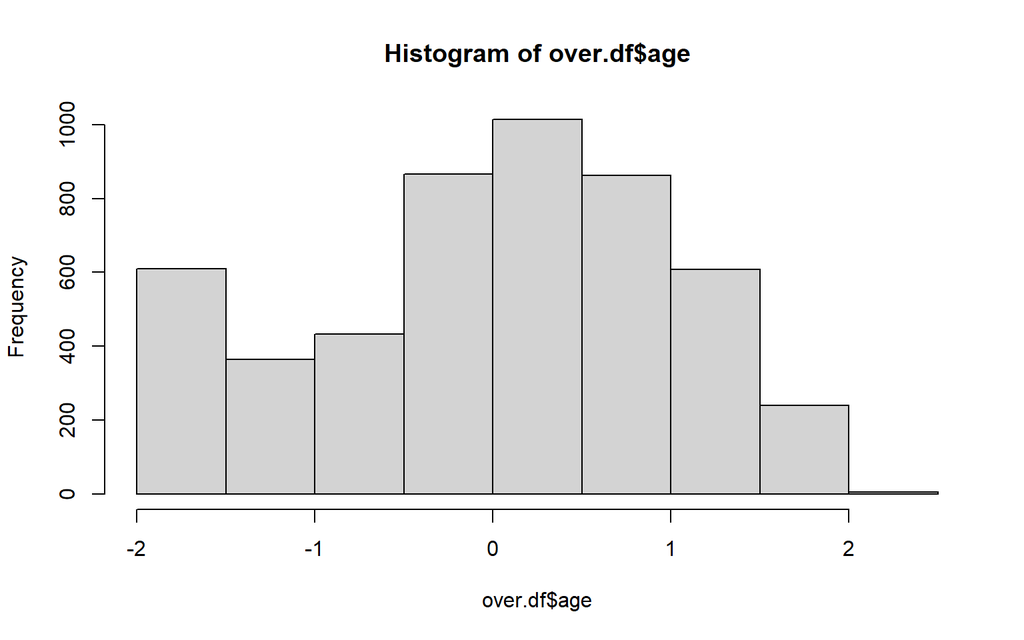

```r
hist(over.df$age)
```

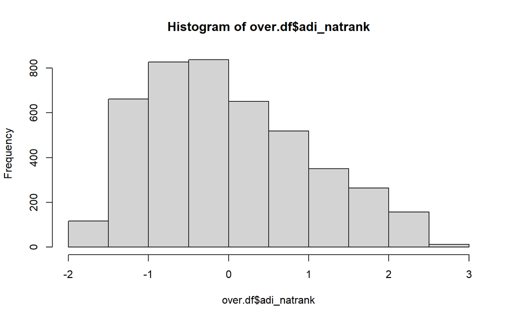

```r
hist(over.df$adi_natrank)
```

### EDA

Here are the variables we are interested: predicted_race gender age adi_natrank

#### preicted_race

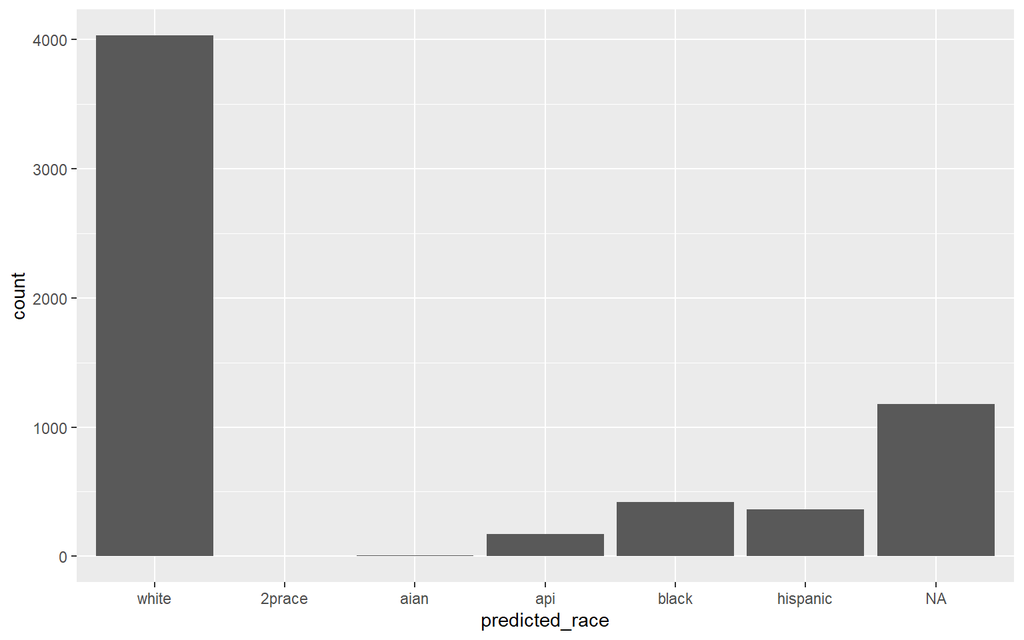

```r
ggplot(data = over.df) +
  geom_bar(mapping = aes(x = predicted_race))
```

```r
summary(over.df$predicted_race)
```

```
##    white   2prace     aian      api    black hispanic     NA's
##     4032        2        9      170      422      365     1177
```

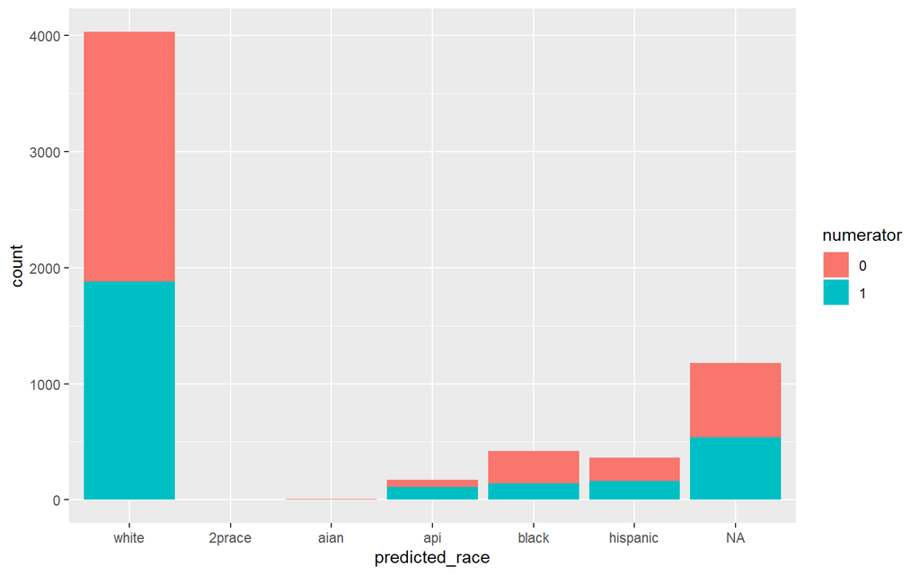

```r
ggplot(data = over.df) +
  geom_bar(mapping = aes(x = predicted_race, fill = numerator))
```

```r
prop.table(table(over.df$numerator, over.df$predicted_race),1)
```

```
##
##            white       2prace         aian          api        black
##   0 0.7960769800 0.0003700962 0.0022205774 0.0225758697 0.1032568468
##   1 0.8185378590 0.0004351610 0.0013054830 0.0474325500 0.0622280244
##
##         hispanic
##   0 0.0754996299
##   1 0.0700609225
```

```r
prop.table(table(over.df$predicted_race,over.df$numerator),1)
```

```
##
##                    0         1
##   white    0.5334821 0.4665179
##   2prace   0.5000000 0.5000000
##   aian     0.6666667 0.3333333
##   api      0.3588235 0.6411765
##   black    0.6611374 0.3388626
##   hispanic 0.5589041 0.4410959
```

#### gender

```r
summary(over.df$gender)
```

```
## FEMALE   MALE   NA's
##   3252   1748   1177
```

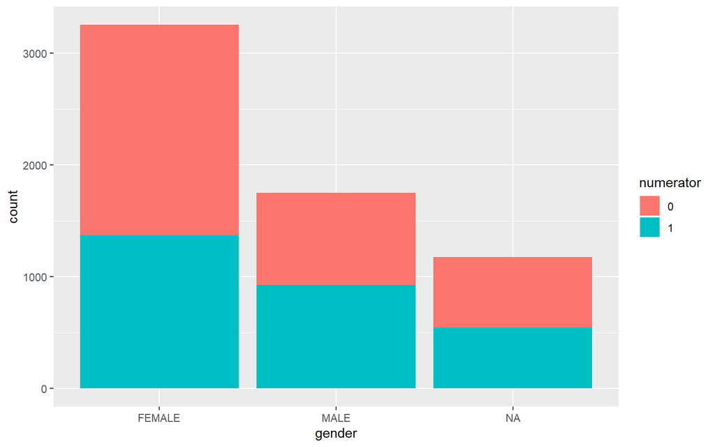

```r
ggplot(data = over.df) +
  geom_bar(mapping = aes(x = gender, fill = numerator))
```

```r
prop.table(table(over.df$numerator, over.df$gender),1)
```

```
##
##        FEMALE      MALE
##   0 0.6954108 0.3045892
##   1 0.5974761 0.4025239
```

#### age

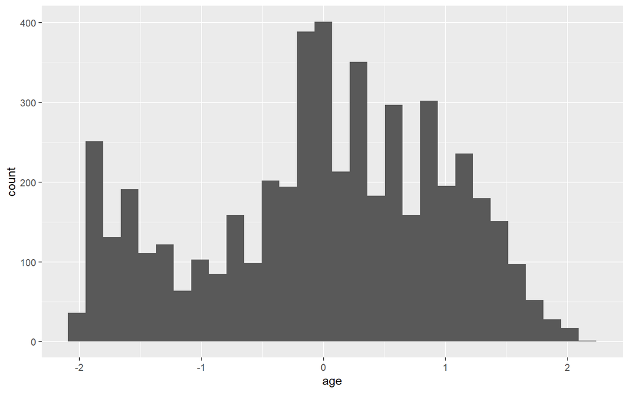

```r
ggplot(data=over.df, aes(x = age)) +
  geom_histogram()
```

```r
# number of NAs
sum(is.na(over.df$age))
```

```
## [1] 1177
```

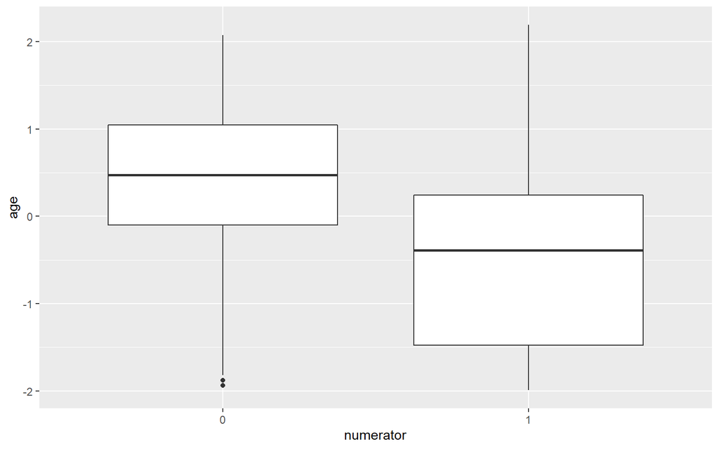

```r
ggplot(data=over.df, aes(x = numerator, y = age)) +
  geom_boxplot()
```

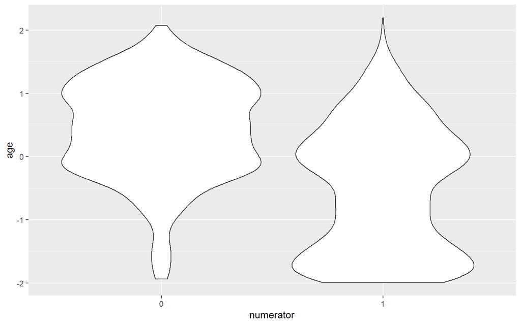

```r
ggplot(data=over.df, aes(x = numerator, y = age)) +
  geom_violin()
```

```r
age_summary <- over.df %>%
  group_by(numerator) %>%
  summarize(n = n(),
         mean = mean(age,na.rm=TRUE),
         sd = sd(age,na.rm=TRUE)
         )
age_summary
```

```
## # A tibble: 2 x 4
##   numerator     n   mean    sd
##   <fct>     <int>  <dbl> <dbl>
## 1 0          3338  0.432 0.782
## 2 1          2839 -0.508 0.990
```

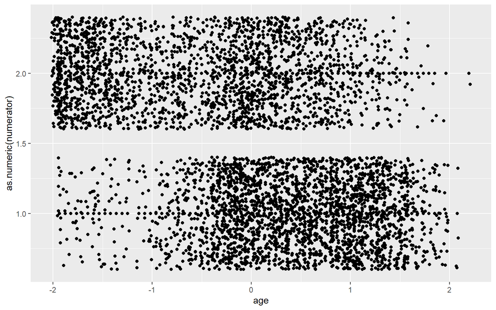

```r
ggplot(data = over.df, aes(x =age, y = as.numeric(numerator) )) +
  geom_point() +
  geom_jitter()
```

#### ndi

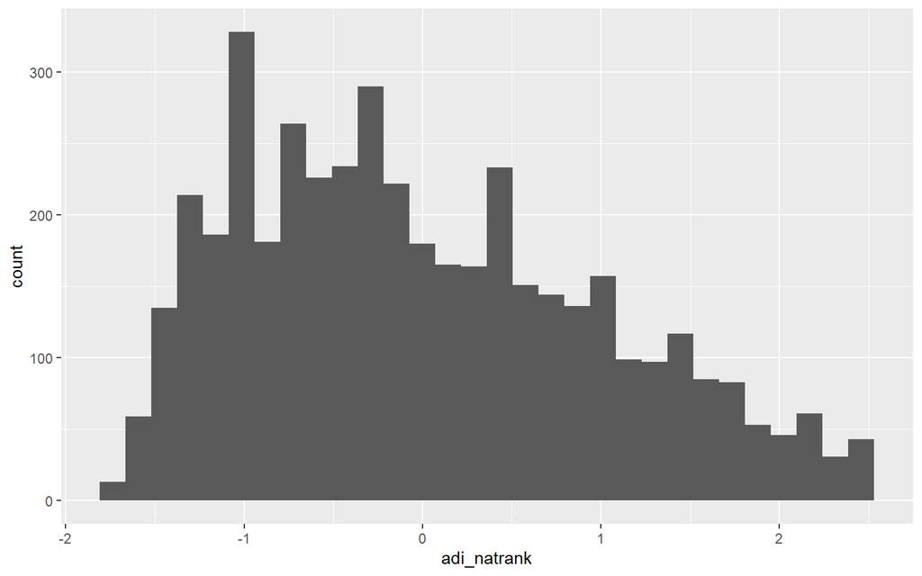

```r
ggplot(data=over.df, aes(x = adi_natrank)) +
  geom_histogram()
```

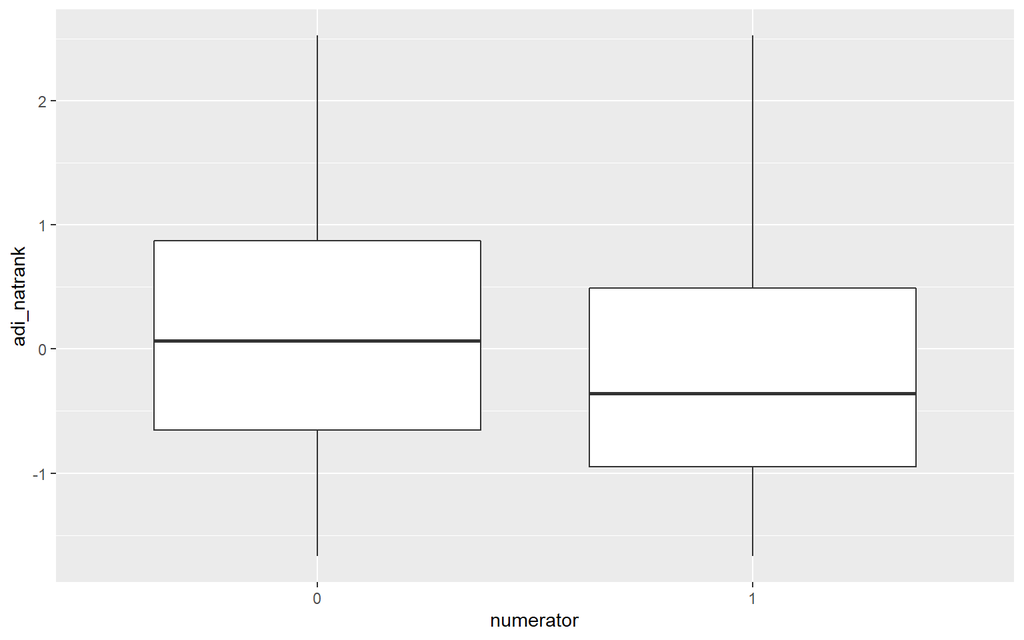

```r
ggplot(data=over.df, aes(x = numerator, y = adi_natrank)) +
  geom_boxplot()
```

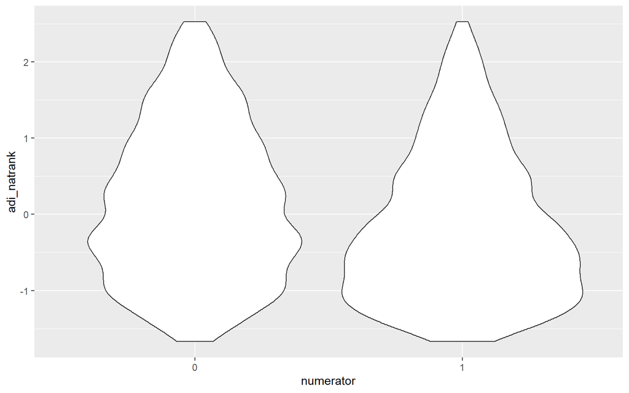

```r
ggplot(data=over.df, aes(x = numerator, y = adi_natrank)) +
  geom_violin()
```

```r
ndi_summary <- over.df %>%
  group_by(numerator) %>%
  summarize(n = n(),
         mean = mean(adi_natrank,na.rm=TRUE),
         median = median(adi_natrank,na.rm=TRUE),
         sd = sd(adi_natrank,na.rm=TRUE)
         )
ndi_summary
```

```
## # A tibble: 2 x 5
##   numerator     n   mean  median    sd
##   <fct>     <int>  <dbl>   <dbl> <dbl>
## 1 0          3338  0.139  0.0673 1.00
## 2 1          2839 -0.164 -0.357  0.971
```

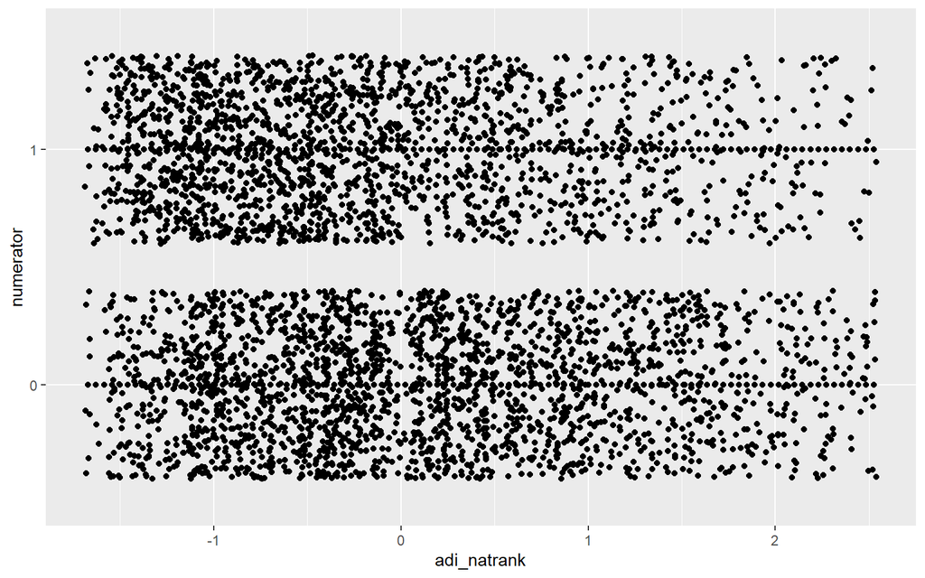

```r
ggplot(data = over.df, aes(x =adi_natrank, y =numerator)) +
  geom_point() +
  geom_jitter()
```

#### race vs. ndi vs numerator

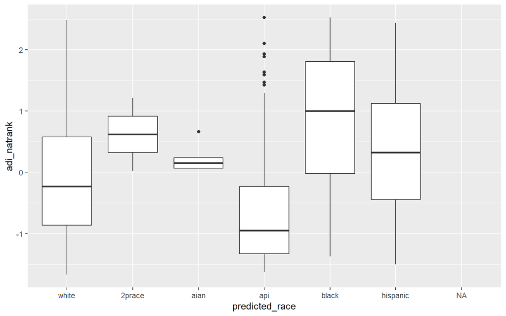

```r
ggplot(over.df, aes(x = predicted_race, y = adi_natrank)) +
  geom_boxplot()
```

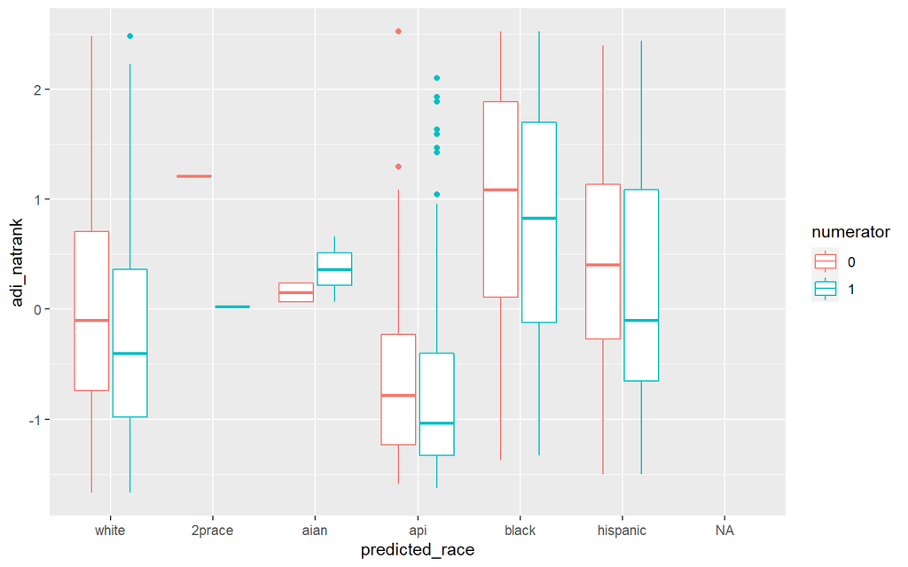

```r
ggplot(over.df, aes(x = predicted_race, y = adi_natrank, color = numerator)) +
  geom_boxplot()
```

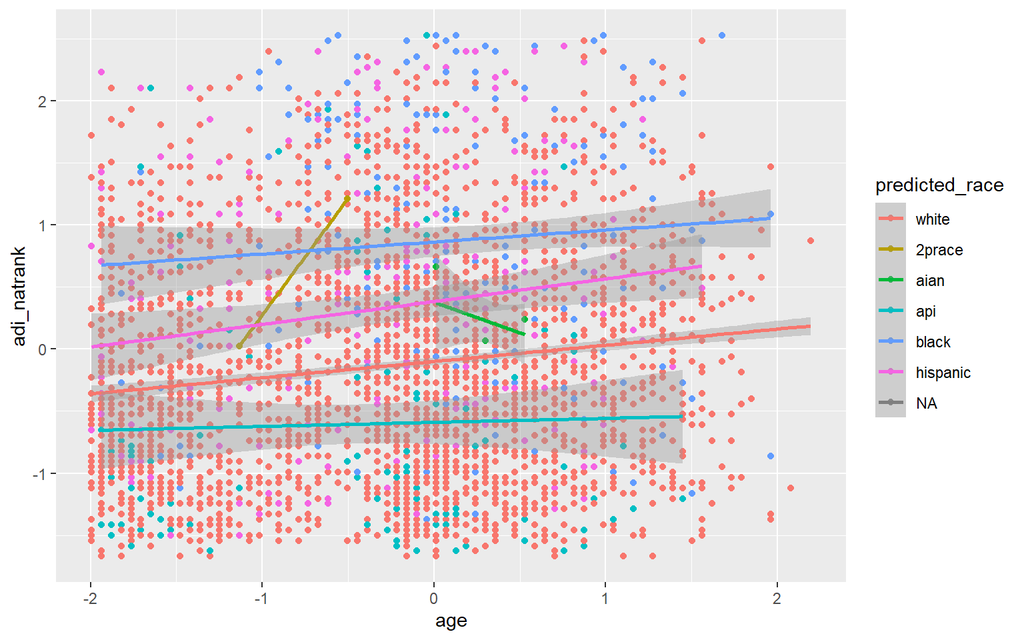

```r
ggplot(over.df, aes(x = age, y = adi_natrank, color = predicted_race)) +
  geom_point() +
  geom_smooth(method = 'lm')
```

### regression

Code and resources from Julian Faraway (2016): Extending the Linear Model with R

note from the data, each observation (row) might not be independent to each other. It is possible that one member has different meausres. Thus we should consider mised effect model with lmer(), actually glmer() that can account for the repeated measures – all the obs are not independent.

try glm:

```r
#note this model assumes all obs are independent
m0.glm <- glm(numerator ~ predicted_race + gender + age + adi_natrank,
                family = "binomial",
                data = over.df)
summary(m0.glm)
```

```
##
## Call:
## glm(formula = numerator ~ predicted_race + gender + age + adi_natrank,
##     family = "binomial", data = over.df)
##
## Deviance Residuals:
##     Min       1Q   Median       3Q      Max
## -2.3796  -0.9447  -0.5260   0.9727   2.4317
##
## Coefficients:
##                        Estimate Std. Error z value Pr(>|z|)
## (Intercept)            -0.32626    0.04627  -7.052 1.77e-12 ***
## predicted_race2prace   -0.45235    1.45329  -0.311    0.756
## predicted_raceaian     -0.35463    0.82020  -0.432    0.665
## predicted_raceapi       0.30663    0.18961   1.617    0.106
## predicted_raceblack    -0.05902    0.13263  -0.445    0.656
## predicted_racehispanic -0.08281    0.13493  -0.614    0.539
## genderMALE              0.45636    0.07365   6.197 5.77e-10 ***
## age                    -1.09846    0.04110 -26.724  < 2e-16 ***
## adi_natrank            -0.19291    0.03667  -5.261 1.43e-07 ***
## ---
## Signif. codes:  0 '***' 0.001 '**' 0.01 '*' 0.05 '.' 0.1 ' ' 1
##
## (Dispersion parameter for binomial family taken to be 1)
##
##     Null deviance: 6066.5  on 4396  degrees of freedom
## Residual deviance: 4970.1  on 4388  degrees of freedom
##   (1780 observations deleted due to missingness)
## AIC: 4988.1
##
## Number of Fisher Scoring iterations: 4
```

#### method 1 - PQL (penalized quasi likelihood)

```r
m0.pql <- glmmPQL(numerator ~ predicted_race + gender + age + adi_natrank,
                random=list(member_number = ~1, ebm_measure_label = ~1),
                family = "binomial",
                data = over.df)
```

```
## iteration 1
```

```
## iteration 2
```

```
## iteration 3
```

```
## iteration 4
```

```
## iteration 5
```

```
## iteration 6
```

```
## iteration 7
```

```
## iteration 8
```

```
## iteration 9
```

```
## iteration 10
```

```r
summary(m0.pql)
```

```
## Linear mixed-effects model fit by maximum likelihood
##   Data: over.df
##   AIC BIC logLik
##    NA  NA     NA
##
## Random effects:
##  Formula: ~1 | member_number
##         (Intercept)
## StdDev:    4.574753
##
##  Formula: ~1 | ebm_measure_label %in% member_number
##         (Intercept)  Residual
## StdDev:    3.852065 0.1425273
##
## Variance function:
##  Structure: fixed weights
##  Formula: ~invwt
## Fixed effects:  numerator ~ predicted_race + gender + age + adi_natrank
##                             Value Std.Error   DF    t-value p-value
## (Intercept)            -0.3550141  0.154199 3150  -2.302309  0.0214
## predicted_race2prace   -1.5734102  4.645363 3150  -0.338706  0.7349
## predicted_raceaian     -0.8424889  3.255473 3150  -0.258792  0.7958
## predicted_raceapi       0.3589951  0.586662 3150   0.611928  0.5406
## predicted_raceblack    -0.1561982  0.451716 3150  -0.345788  0.7295
## predicted_racehispanic -0.3525018  0.440259 3150  -0.800669  0.4234
## genderMALE              1.8170387  0.247489 3150   7.341910  0.0000
## age                    -2.7414468  0.124802 3150 -21.966398  0.0000
## adi_natrank            -0.5053194  0.122332 3150  -4.130712  0.0000
##  Correlation:
##                        (Intr) prdc_2 prdctd_rcn prdctd_rcp prdctd_rcb
## predicted_race2prace   -0.033
## predicted_raceaian     -0.049  0.002
## predicted_raceapi      -0.174  0.005  0.007
## predicted_raceblack    -0.305  0.013  0.018      0.039
## predicted_racehispanic -0.260  0.012  0.013      0.055      0.115
## genderMALE             -0.534  0.018  0.025      0.009      0.065
## age                     0.100  0.020 -0.016      0.035     -0.049
## adi_natrank             0.094 -0.021 -0.014      0.083     -0.256
##                        prdctd_rch gnMALE age
## predicted_race2prace
## predicted_raceaian
## predicted_raceapi
## predicted_raceblack
## predicted_racehispanic
## genderMALE              0.016
## age                     0.045      0.001
## adi_natrank            -0.130      0.013 -0.074
##
## Standardized Within-Group Residuals:
##        Min         Q1        Med         Q3        Max
## -7.0410001 -0.3392845 -0.1777136  0.3310693  7.0066445
##
## Number of Observations: 4397
## Number of Groups:
##                        member_number ebm_measure_label %in% member_number
##                                 3159                                 4390
```

According to Faraway(2016), this method is based on the linearized model and rather dubious assumptions explained in 10.2, and the binary response can lead to biased estimates of the coefficients.

#### method 2 - glmer

```r
#overall model
m0.glmer <- glmer(numerator ~  predicted_race +
                    gender +
                    age +
                    adi_natrank +
                    (1|member_number) +
                    (1|ebm_measure_label),
                family = binomial(link="logit"),
                data = over.df,
                control=glmerControl(optimizer="bobyqa",optCtrl=list(maxfun=2e5)))
summary(m0.glmer)
```

```
## Generalized linear mixed model fit by maximum likelihood (Laplace
##   Approximation) [glmerMod]
##  Family: binomial  ( logit )
## Formula: numerator ~ predicted_race + gender + age + adi_natrank + (1 |
##     member_number) + (1 | ebm_measure_label)
##    Data: over.df
## Control: glmerControl(optimizer = "bobyqa", optCtrl = list(maxfun = 2e+05))
##
##      AIC      BIC   logLik deviance df.resid
##   3546.7   3617.0  -1762.4   3524.7     4386
##
## Scaled residuals:
##     Min      1Q  Median      3Q     Max
## -4.4883 -0.4356 -0.1236  0.4799  6.7756
##
## Random effects:
##  Groups            Name        Variance Std.Dev.
##  member_number     (Intercept) 0.1776   0.4214
##  ebm_measure_label (Intercept) 3.8795   1.9696
## Number of obs: 4397, groups:  member_number, 3159; ebm_measure_label, 9
##
## Fixed effects:
##                        Estimate Std. Error z value Pr(>|z|)
## (Intercept)            -1.02840    0.66203  -1.553  0.12033
## predicted_race2prace   -0.68949    1.96778  -0.350  0.72605
## predicted_raceaian      1.45211    0.94822   1.531  0.12567
## predicted_raceapi       0.04342    0.22418   0.194  0.84641
## predicted_raceblack    -0.11649    0.17071  -0.682  0.49498
## predicted_racehispanic -0.46622    0.16289  -2.862  0.00421 **
## genderMALE              0.22109    0.10165   2.175  0.02964 *
## age                    -0.51702    0.05844  -8.847  < 2e-16 ***
## adi_natrank            -0.10994    0.04675  -2.352  0.01869 *
## ---
## Signif. codes:  0 '***' 0.001 '**' 0.01 '*' 0.05 '.' 0.1 ' ' 1
##
## Correlation of Fixed Effects:
##             (Intr) prdc_2 prdctd_rcn prdctd_rcp prdctd_rcb prdctd_rch gnMALE
## prdctd_rc2p -0.002
## predctd_rcn -0.014  0.002
## predctd_rcp -0.010  0.006  0.005
## prdctd_rcbl -0.027  0.012  0.023      0.040
## prdctd_rchs -0.020  0.011  0.009      0.053      0.118
## genderMALE  -0.060  0.010  0.041     -0.017      0.066      0.027
## age         -0.017  0.020  0.005     -0.001     -0.024      0.036      0.037
## adi_natrank  0.003 -0.018 -0.013      0.075     -0.256     -0.130      0.041
##             age
## prdctd_rc2p
## predctd_rcn
## predctd_rcp
## prdctd_rcbl
## prdctd_rchs
## genderMALE
## age
## adi_natrank  0.012
```

```r
#this model does not include ndi.
m0.glmer.race <- glmer(numerator ~  predicted_race +
                         gender +
                         age +
                         (1|member_number) +
                         (1|ebm_measure_label),
                family = binomial(link="logit"),
                data = over.df,
                control=glmerControl(optimizer="bobyqa",optCtrl=list(maxfun=2e5)))
summary(m0.glmer.race)
```

```
## Generalized linear mixed model fit by maximum likelihood (Laplace
##   Approximation) [glmerMod]
##  Family: binomial  ( logit )
## Formula: numerator ~ predicted_race + gender + age + (1 | member_number) +
##     (1 | ebm_measure_label)
##    Data: over.df
## Control: glmerControl(optimizer = "bobyqa", optCtrl = list(maxfun = 2e+05))
##
##      AIC      BIC   logLik deviance df.resid
##   3995.8   4061.0  -1987.9   3975.8     4990
##
## Scaled residuals:
##     Min      1Q  Median      3Q     Max
## -4.3071 -0.4108 -0.1154  0.4791  7.3306
##
## Random effects:
##  Groups            Name        Variance Std.Dev.
##  member_number     (Intercept) 0.1446   0.3803
##  ebm_measure_label (Intercept) 4.1297   2.0322
## Number of obs: 5000, groups:  member_number, 3581; ebm_measure_label, 9
##
## Fixed effects:
##                        Estimate Std. Error z value Pr(>|z|)
## (Intercept)            -1.05383    0.68259  -1.544   0.1226
## predicted_race2prace   -0.78657    1.89227  -0.416   0.6776
## predicted_raceaian      1.53528    0.92388   1.662   0.0966 .
## predicted_raceapi       0.07406    0.20781   0.356   0.7216
## predicted_raceblack    -0.17299    0.15456  -1.119   0.2630
## predicted_racehispanic -0.61014    0.14840  -4.111 3.93e-05 ***
## genderMALE              0.23761    0.09576   2.481   0.0131 *
## age                    -0.49795    0.05445  -9.145  < 2e-16 ***
## ---
## Signif. codes:  0 '***' 0.001 '**' 0.01 '*' 0.05 '.' 0.1 ' ' 1
##
## Correlation of Fixed Effects:
##             (Intr) prdc_2 prdctd_rcn prdctd_rcp prdctd_rcb prdctd_rch gnMALE
## prdctd_rc2p -0.001
## predctd_rcn -0.012  0.001
## predctd_rcp -0.009  0.007  0.005
## prdctd_rcbl -0.025  0.008  0.019      0.062
## prdctd_rchs -0.017  0.009  0.007      0.066      0.091
## genderMALE  -0.054  0.010  0.040     -0.025      0.074      0.024
## age         -0.015  0.019  0.006     -0.001     -0.026      0.045      0.037
```

```r
#model exlude race
m0.glmer.ndi <- glmer(numerator ~
                    gender +
                    age +
                    adi_natrank +
                    (1|member_number) +
                    (1|ebm_measure_label),
                family = binomial(link="logit"),
                data = over.df,
                control=glmerControl(optimizer="bobyqa",optCtrl=list(maxfun=2e5)))
summary(m0.glmer.ndi)
```

```
## Generalized linear mixed model fit by maximum likelihood (Laplace
##   Approximation) [glmerMod]
##  Family: binomial  ( logit )
## Formula: numerator ~ gender + age + adi_natrank + (1 | member_number) +
##     (1 | ebm_measure_label)
##    Data: over.df
## Control: glmerControl(optimizer = "bobyqa", optCtrl = list(maxfun = 2e+05))
##
##      AIC      BIC   logLik deviance df.resid
##   3547.1   3585.4  -1767.5   3535.1     4391
##
## Scaled residuals:
##     Min      1Q  Median      3Q     Max
## -4.3185 -0.4436 -0.1247  0.4840  6.2129
##
## Random effects:
##  Groups            Name        Variance Std.Dev.
##  member_number     (Intercept) 0.1868   0.4322
##  ebm_measure_label (Intercept) 3.8275   1.9564
## Number of obs: 4397, groups:  member_number, 3159; ebm_measure_label, 9
##
## Fixed effects:
##             Estimate Std. Error z value Pr(>|z|)
## (Intercept) -1.06603    0.65733  -1.622  0.10485
## genderMALE   0.22951    0.10121   2.268  0.02334 *
## age         -0.51609    0.05830  -8.852  < 2e-16 ***
## adi_natrank -0.13398    0.04468  -2.998  0.00271 **
## ---
## Signif. codes:  0 '***' 0.001 '**' 0.01 '*' 0.05 '.' 0.1 ' ' 1
##
## Correlation of Fixed Effects:
##             (Intr) gnMALE age
## genderMALE  -0.058
## age         -0.016  0.038
## adi_natrank -0.005  0.064  0.011
```

```r
Anova(m0.glmer,type="II")
```

```
## Analysis of Deviance Table (Type II Wald chisquare tests)
##
## Response: numerator
##                  Chisq Df Pr(>Chisq)
## predicted_race 10.9915  5    0.05155 .
## gender          4.7303  1    0.02964 *
## age            78.2723  1    < 2e-16 ***
## adi_natrank     5.5305  1    0.01869 *
## ---
## Signif. codes:  0 '***' 0.001 '**' 0.01 '*' 0.05 '.' 0.1 ' ' 1
```

```r
r.squaredGLMM(m0.glmer)
```

```
##                    R2m       R2c
## theoretical 0.04328461 0.5715928
## delta       0.03809952 0.5031214
```

```r
#diagnostic plots
#plot(m0.glmer)
```

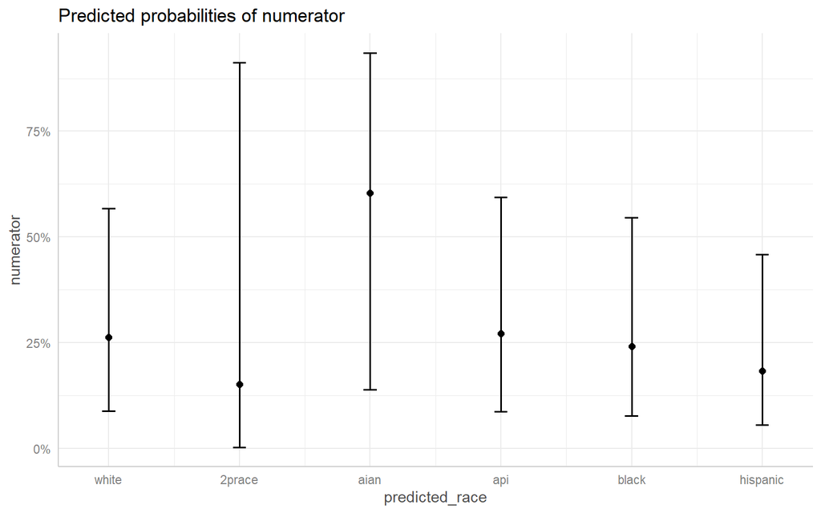

```r
me1 <- ggpredict(m0.glmer, "predicted_race")
plot(me1)
```

```r
me2 <- ggpredict(m0.glmer, "adi_natrank")
```

```
## Data were 'prettified'. Consider using `terms="adi_natrank [all]"` to get smooth plots.
```

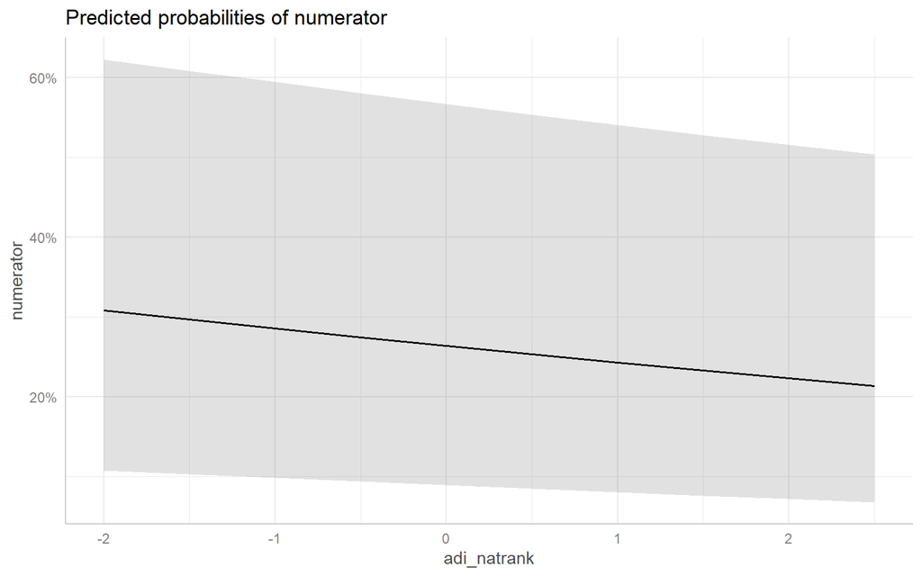

```r
plot(me2)
```

```r
exp(coef(summary(m0.glmer))[ , "Estimate"])
```

```
##            (Intercept)   predicted_race2prace     predicted_raceaian
##              0.3575796              0.5018336              4.2721214
##      predicted_raceapi    predicted_raceblack predicted_racehispanic
##              1.0443815              0.8900353              0.6273690
##             genderMALE                    age            adi_natrank
##              1.2474332              0.5962964              0.8958850
```

#### method 3 - Bayesian MEMs

```r
m0.bayes <- bglmer(numerator ~  predicted_race +
                     gender +
                     age +
                     adi_natrank +
                     (1|member_number) +
                     (1|ebm_measure_label),
                family = binomial(link="logit"),
                data = over.df,
                control=glmerControl(optimizer = "bobyqa"))
summary(m0.bayes)
```

```
## Cov prior  : member_number ~ wishart(df = 3.5, scale = Inf, posterior.scale = cov, common.scale = TRUE)
##            : ebm_measure_label ~ wishart(df = 3.5, scale = Inf, posterior.scale = cov, common.scale = TRUE)
## Prior dev  : -0.2679
##
## Generalized linear mixed model fit by maximum likelihood (Laplace
##   Approximation) [bglmerMod]
##  Family: binomial  ( logit )
## Formula: numerator ~ predicted_race + gender + age + adi_natrank + (1 |
##     member_number) + (1 | ebm_measure_label)
##    Data: over.df
## Control: glmerControl(optimizer = "bobyqa")
##
##      AIC      BIC   logLik deviance df.resid
##   3547.1   3617.4  -1762.5   3525.1     4386
##
## Scaled residuals:
##     Min      1Q  Median      3Q     Max
## -4.3740 -0.4319 -0.1217  0.4750  6.6486
##
## Random effects:
##  Groups            Name        Variance Std.Dev.
##  member_number     (Intercept) 0.2502   0.5002
##  ebm_measure_label (Intercept) 4.7780   2.1859
## Number of obs: 4397, groups:  member_number, 3159; ebm_measure_label, 9
##
## Fixed effects:
##                        Estimate Std. Error z value Pr(>|z|)
## (Intercept)            -1.04139    0.73347  -1.420  0.15567
## predicted_race2prace   -0.69623    1.98329  -0.351  0.72555
## predicted_raceaian      1.47697    0.96564   1.530  0.12613
## predicted_raceapi       0.04390    0.22626   0.194  0.84616
## predicted_raceblack    -0.11633    0.17230  -0.675  0.49958
## predicted_racehispanic -0.47161    0.16450  -2.867  0.00414 **
## genderMALE              0.22396    0.10247   2.186  0.02885 *
## age                    -0.52233    0.05871  -8.897  < 2e-16 ***
## adi_natrank            -0.11145    0.04714  -2.364  0.01807 *
## ---
## Signif. codes:  0 '***' 0.001 '**' 0.01 '*' 0.05 '.' 0.1 ' ' 1
##
## Correlation of Fixed Effects:
##             (Intr) prdc_2 prdctd_rcn prdctd_rcp prdctd_rcb prdctd_rch gnMALE
## prdctd_rc2p -0.002
## predctd_rcn -0.012  0.001
## predctd_rcp -0.009  0.006  0.004
## prdctd_rcbl -0.024  0.012  0.023      0.040
## prdctd_rchs -0.018  0.011  0.010      0.053      0.118
## genderMALE  -0.054  0.010  0.040     -0.018      0.065      0.027
## age         -0.016  0.020  0.006     -0.001     -0.024      0.034      0.038
## adi_natrank  0.003 -0.018 -0.013      0.075     -0.256     -0.131      0.041
##             age
## prdctd_rc2p
## predctd_rcn
## predctd_rcp
## prdctd_rcbl
## prdctd_rchs
## genderMALE
## age
## adi_natrank  0.009
```

### Test for significance of variables

```r
#lrMod1.pb <- mixed(numerator ~ predicted_race + gender + age + adi_natrank + (1|member_number) + (1|ebm_measure_label),
#                data=over.df,
#                family="binomial", method='LRT', args_test=list(nsim=1000),
#                control=glmerControl(optimizer = "bobyqa"))

#summary(lrMod1.pb)
```

#### test random effect

```r
m0.glmer <- glmer(numerator ~  predicted_race +
                    gender +
                    age +
                    adi_natrank +
                    (1|member_number) +
                    (1|ebm_measure_label),
                family = binomial(link="logit"),
                data = over.df)

m0.glmer.r <- glmer(numerator ~  predicted_race +
                      gender +
                      age +
                      adi_natrank +
                      (1|member_number),
                family = binomial(link="logit"),
                data = over.df)

anova(m0.glmer, m0.glmer.r)
```

```
## Data: over.df
## Models:
## m0.glmer.r: numerator ~ predicted_race + gender + age + adi_natrank + (1 | member_number)
## m0.glmer: numerator ~ predicted_race + gender + age + adi_natrank + (1 | member_number) + (1 | ebm_measure_label)
##            npar    AIC    BIC  logLik deviance  Chisq Df Pr(>Chisq)
## m0.glmer.r   10 4843.4 4907.3 -2411.7   4823.4
## m0.glmer     11 3546.7 3617.0 -1762.4   3524.7 1298.7  1  < 2.2e-16 ***
## ---
## Signif. codes:  0 '***' 0.001 '**' 0.01 '*' 0.05 '.' 0.1 ' ' 1
```

Thus, we should include the random effect term: (1|ebm_measure_label)

```r
# test the effect predicted_race:ndi
m0.glmer <- glmer(numerator ~  predicted_race +
                    gender +
                    age +
                    adi_natrank +
                    (1|member_number) +
                    (1|ebm_measure_label),
                family = binomial(link="logit"),
                data = over.df,
                control = glmerControl(tolPwrss=1e-3)
                )

m0.glmer.racendi <- glmer(numerator ~  predicted_race +
                            gender +
                            age +
                            adi_natrank +
                            predicted_race:adi_natrank +
                            (1|member_number) +
                            (1|ebm_measure_label),
                family = binomial(link="logit"),
                data = over.df,
                control = glmerControl(tolPwrss=1e-3))


anova(m0.glmer, m0.glmer.racendi)
```

```
## Data: over.df
## Models:
## m0.glmer: numerator ~ predicted_race + gender + age + adi_natrank + (1 | member_number) + (1 | ebm_measure_label)
## m0.glmer.racendi: numerator ~ predicted_race + gender + age + adi_natrank + predicted_race:adi_natrank + (1 | member_number) + (1 | ebm_measure_label)
##                  npar    AIC  BIC  logLik deviance  Chisq Df Pr(>Chisq)
## m0.glmer           11 3546.7 3617 -1762.4   3524.7
## m0.glmer.racendi   16 3553.8 3656 -1760.9   3521.8 2.9629  5     0.7057
```

```r
summary(m0.glmer.racendi)
```

```
## Generalized linear mixed model fit by maximum likelihood (Laplace
##   Approximation) [glmerMod]
##  Family: binomial  ( logit )
## Formula:
## numerator ~ predicted_race + gender + age + adi_natrank + predicted_race:adi_natrank +
##     (1 | member_number) + (1 | ebm_measure_label)
##    Data: over.df
## Control: glmerControl(tolPwrss = 0.001)
##
##      AIC      BIC   logLik deviance df.resid
##   3553.8   3656.0  -1760.9   3521.8     4381
##
## Scaled residuals:
##     Min      1Q  Median      3Q     Max
## -4.4598 -0.4392 -0.1234  0.4797  6.2429
##
## Random effects:
##  Groups            Name        Variance Std.Dev.
##  member_number     (Intercept) 0.1752   0.4186
##  ebm_measure_label (Intercept) 3.8540   1.9632
## Number of obs: 4397, groups:  member_number, 3159; ebm_measure_label, 9
##
## Fixed effects:
##                                      Estimate Std. Error z value Pr(>|z|)
## (Intercept)                          -1.02763    0.66002  -1.557  0.11948
## predicted_race2prace                  7.43419  114.72008   0.065  0.94833
## predicted_raceaian                    0.62079    1.59042   0.390  0.69629
## predicted_raceapi                     0.06469    0.25671   0.252  0.80104
## predicted_raceblack                  -0.23499    0.20503  -1.146  0.25175
## predicted_racehispanic               -0.49154    0.16640  -2.954  0.00314 **
## genderMALE                            0.21490    0.10187   2.109  0.03490 *
## age                                  -0.51537    0.05721  -9.008  < 2e-16 ***
## adi_natrank                          -0.14376    0.05370  -2.677  0.00742 **
## predicted_race2prace:adi_natrank    -17.23569 1200.05648  -0.014  0.98854
## predicted_raceaian:adi_natrank        3.47166    5.38638   0.645  0.51923
## predicted_raceapi:adi_natrank         0.05918    0.22966   0.258  0.79666
## predicted_raceblack:adi_natrank       0.18292    0.15800   1.158  0.24697
## predicted_racehispanic:adi_natrank    0.12499    0.15237   0.820  0.41205
## ---
## Signif. codes:  0 '***' 0.001 '**' 0.01 '*' 0.05 '.' 0.1 ' ' 1
```

```
##
## Correlation matrix not shown by default, as p = 14 > 12.
## Use print(x, correlation=TRUE)  or
##     vcov(x)        if you need it
```

```
## optimizer (Nelder_Mead) convergence code: 0 (OK)
## unable to evaluate scaled gradient
## Model failed to converge: degenerate  Hessian with 1 negative eigenvalues
```

```r
Anova(m0.glmer.racendi, type =  "II")
```

```
## Analysis of Deviance Table (Type II Wald chisquare tests)
##
## Response: numerator
##                              Chisq Df Pr(>Chisq)
## predicted_race             10.4470  5    0.06352 .
## gender                      4.4500  1    0.03490 *
## age                        81.1481  1    < 2e-16 ***
## adi_natrank                 5.5254  1    0.01874 *
## predicted_race:adi_natrank  2.2356  5    0.81567
## ---
## Signif. codes:  0 '***' 0.001 '**' 0.01 '*' 0.05 '.' 0.1 ' ' 1
```

No need for the interaction: predicted_race:adi_natrank

```r
# test the effect gender:ndi
m0.glmer <- glmer(numerator ~  predicted_race +
                    gender +
                    age +
                    adi_natrank +
                    (1|member_number) +
                    (1|ebm_measure_label),
                family = binomial(link="logit"),
                data = over.df)

m0.glmer.genderndi <- glmer(numerator ~  predicted_race +
                              gender +
                              age +
                              adi_natrank +
                              gender:adi_natrank +
                              (1|member_number) +
                              (1|ebm_measure_label),
                family = binomial(link="logit"),
                data = over.df)


anova(m0.glmer, m0.glmer.genderndi)
```

```
## Data: over.df
## Models:
## m0.glmer: numerator ~ predicted_race + gender + age + adi_natrank + (1 | member_number) + (1 | ebm_measure_label)
## m0.glmer.genderndi: numerator ~ predicted_race + gender + age + adi_natrank + gender:adi_natrank + (1 | member_number) + (1 | ebm_measure_label)
##                    npar    AIC    BIC  logLik deviance  Chisq Df Pr(>Chisq)
## m0.glmer             11 3546.7 3617.0 -1762.4   3524.7
## m0.glmer.genderndi   12 3548.6 3625.2 -1762.3   3524.6 0.1331  1     0.7152
```

No need for the interaction: gender:adi_natrank

```r
# test the effect age:ndi
m0.glmer <- glmer(numerator ~  predicted_race +
                    gender +
                    age +
                    adi_natrank +
                    (1|member_number) +
                    (1|ebm_measure_label),
                family = binomial(link="logit"),
                data = over.df)

m0.glmer.agendi <- glmer(numerator ~  predicted_race +
                           gender +
                           age +
                           adi_natrank +
                           age:adi_natrank +
                           (1|member_number) +
                           (1|ebm_measure_label),
                family = binomial(link="logit"),
                data = over.df)


anova(m0.glmer, m0.glmer.agendi)
```

```
## Data: over.df
## Models:
## m0.glmer: numerator ~ predicted_race + gender + age + adi_natrank + (1 | member_number) + (1 | ebm_measure_label)
## m0.glmer.agendi: numerator ~ predicted_race + gender + age + adi_natrank + age:adi_natrank + (1 | member_number) + (1 | ebm_measure_label)
##                 npar    AIC    BIC  logLik deviance Chisq Df Pr(>Chisq)
## m0.glmer          11 3546.7 3617.0 -1762.4   3524.7
## m0.glmer.agendi   12 3544.6 3621.3 -1760.3   3520.6 4.103  1    0.04281 *
## ---
## Signif. codes:  0 '***' 0.001 '**' 0.01 '*' 0.05 '.' 0.1 ' ' 1
```

the interaction age:ndi appears to be signicant, take a look at the summary output

```r
summary(m0.glmer.agendi)
```

```
## Generalized linear mixed model fit by maximum likelihood (Laplace
##   Approximation) [glmerMod]
##  Family: binomial  ( logit )
## Formula:
## numerator ~ predicted_race + gender + age + adi_natrank + age:adi_natrank +
##     (1 | member_number) + (1 | ebm_measure_label)
##    Data: over.df
##
##      AIC      BIC   logLik deviance df.resid
##   3544.6   3621.3  -1760.3   3520.6     4385
##
## Scaled residuals:
##     Min      1Q  Median      3Q     Max
## -4.9439 -0.4327 -0.1246  0.4719  6.6289
##
## Random effects:
##  Groups            Name        Variance Std.Dev.
##  member_number     (Intercept) 0.1806   0.425
##  ebm_measure_label (Intercept) 3.9215   1.980
## Number of obs: 4397, groups:  member_number, 3159; ebm_measure_label, 9
##
## Fixed effects:
##                        Estimate Std. Error z value Pr(>|z|)
## (Intercept)            -1.04472    0.66597  -1.569  0.11671
## predicted_race2prace   -0.65446    1.98572  -0.330  0.74171
## predicted_raceaian      1.46317    0.95072   1.539  0.12380
## predicted_raceapi       0.04048    0.22478   0.180  0.85709
## predicted_raceblack    -0.11867    0.16988  -0.699  0.48483
## predicted_racehispanic -0.45974    0.16267  -2.826  0.00471 **
## genderMALE              0.23281    0.10192   2.284  0.02236 *
## age                    -0.50871    0.05862  -8.678  < 2e-16 ***
## adi_natrank            -0.09992    0.04687  -2.132  0.03301 *
## age:adi_natrank         0.10690    0.05191   2.059  0.03948 *
## ---
## Signif. codes:  0 '***' 0.001 '**' 0.01 '*' 0.05 '.' 0.1 ' ' 1
##
## Correlation of Fixed Effects:
##             (Intr) prdc_2 prdctd_rcn prdctd_rcp prdctd_rcb prdctd_rch gnMALE
## prdctd_rc2p -0.002
## predctd_rcn -0.014  0.001
## predctd_rcp -0.010  0.006  0.005
## prdctd_rcbl -0.027  0.012  0.023      0.041
## prdctd_rchs -0.019  0.011  0.009      0.053      0.118
## genderMALE  -0.060  0.010  0.041     -0.017      0.066      0.026
## age         -0.018  0.020  0.006     -0.003     -0.028      0.037      0.038
## adi_natrank -0.001 -0.017 -0.010      0.074     -0.256     -0.127      0.044
## age:d_ntrnk -0.013  0.007  0.010     -0.005     -0.011      0.016      0.060
##             age    ad_ntr
## prdctd_rc2p
## predctd_rcn
## predctd_rcp
## prdctd_rcbl
## prdctd_rchs
## genderMALE
## age
## adi_natrank  0.036
## age:d_ntrnk  0.040  0.094
```

Visualize age:ndi interaction

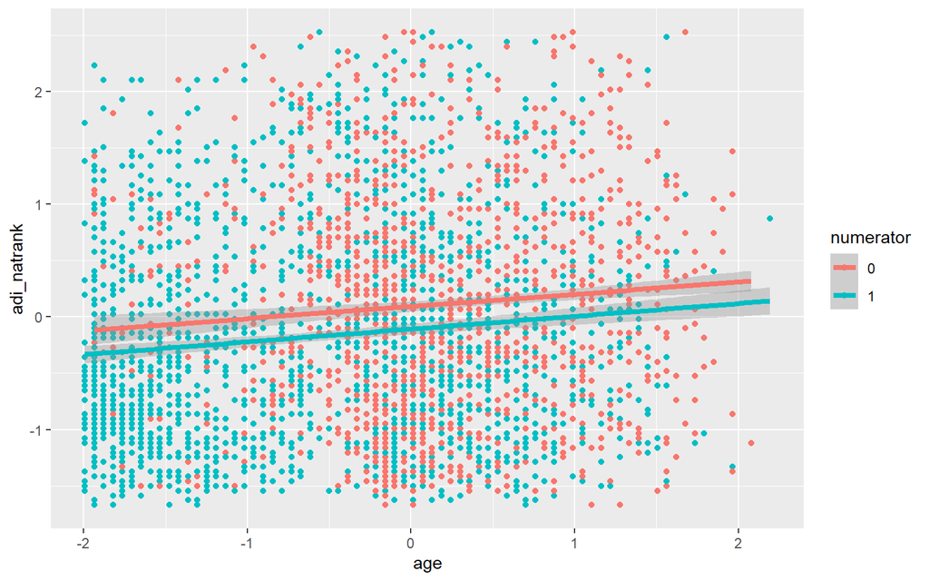

```r
ggplot(over.df, aes(x = age, y = adi_natrank, color = numerator)) +
  geom_point() +
  geom_smooth(method='lm',size=1.5)
```

### goodness-of-fit

Test correlation between ndi and race

```r
model.lm <- lm(adi_natrank ~ predicted_race, data = over.df)
summary(model.lm)
```

```
##
## Call:
## lm(formula = adi_natrank ~ predicted_race, data = over.df)
##
## Residuals:
##     Min      1Q  Median      3Q     Max
## -2.2706 -0.7657 -0.1299  0.6756  3.1302
##
## Coefficients:
##                        Estimate Std. Error t value Pr(>|t|)
## (Intercept)            -0.09955    0.01594  -6.246 4.62e-10 ***
## predicted_race2prace    0.71796    0.67227   1.068    0.286
## predicted_raceaian      0.30464    0.33642   0.906    0.365
## predicted_raceapi      -0.50465    0.07897  -6.390 1.83e-10 ***
## predicted_raceblack     0.99617    0.05173  19.257  < 2e-16 ***
## predicted_racehispanic  0.45104    0.05654   7.978 1.89e-15 ***
## ---
## Signif. codes:  0 '***' 0.001 '**' 0.01 '*' 0.05 '.' 0.1 ' ' 1
##
## Residual standard error: 0.9505 on 4391 degrees of freedom
##   (1780 observations deleted due to missingness)
## Multiple R-squared:  0.09765,    Adjusted R-squared:  0.09662
## F-statistic: 95.03 on 5 and 4391 DF,  p-value: < 2.2e-16
```

```r
rsq <- summary(model.lm)$r.squared
rsq
```

```
## [1] 0.09764765
```

```r
kruskal.test(adi_natrank ~ predicted_race, data = over.df)
```

```
##
##  Kruskal-Wallis rank sum test
##
## data:  adi_natrank by predicted_race
## Kruskal-Wallis chi-squared = 362.55, df = 5, p-value < 2.2e-16
```

```r
r.squaredGLMM(m0.glmer)
```

```
##                    R2m       R2c
## theoretical 0.04328506 0.5715895
## delta       0.03809990 0.5031184
```

```r
summary(m0.glmer)$varcor
```

```
##  Groups            Name        Std.Dev.
##  member_number     (Intercept) 0.42138
##  ebm_measure_label (Intercept) 1.96962
```

```r
# entire model: fixed + random
lrAcc(m0.glmer, 'numerator')
```

```
## [1] 0.8335229
```

```r
#baseline is the intercept only model and random effets
baselineAcc(m0.glmer, 'numerator')
```

```
## [1] 0.5405959
```

```r
#fixed effects only
lrAcc(m0.glmer, 'numerator', use.ranef=FALSE)
```

```
## [1] 0.6022288
```

## Underuse EBM

### Data cleaning

```r
under.df <- read.csv("C:/Users/leo.zhou/Desktop/Equity OKR/R/data/underuse_df.csv",
                    na.strings=c("","NA"))
nrow(under.df)
```

```
## [1] 14758
```

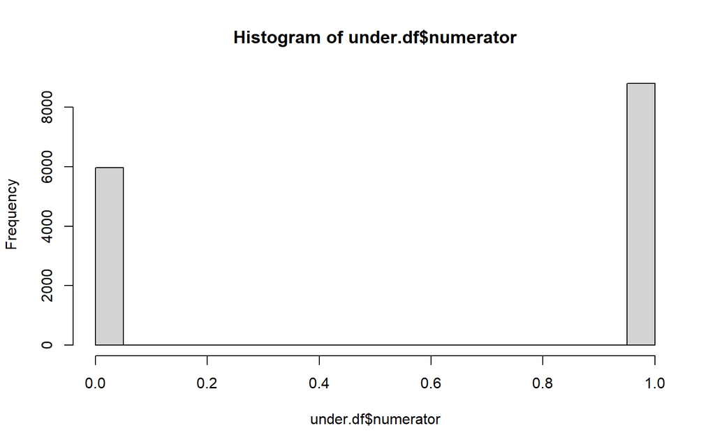

```r
hist(under.df$numerator)
```

```r
under.df$ci_measure_cat <- as.factor(under.df$ci_measure_cat)
levels(under.df$ci_measure_cat)
```

```
## [1] "Access/Availability of Care" "Diabetes"
## [3] "Medication Management"       "Prevention and Screening"
## [5] "Utilization"
```

```r
#change the numerator to factor 0 and 1
under.df$numerator <- as.factor(under.df$numerator)
levels(under.df$numerator)
```

```
## [1] "0" "1"
```

```r
summary(under.df$numerator)
```

```
##    0    1
## 5967 8791
```

```r
under.df$denominator <- as.factor(under.df$denominator )
summary(under.df$denominator)
```

```
##     0     1
##    83 14675
```

```r
#change the ndi to numeric
under.df$adi_natrank <- as.numeric(under.df$adi_natrank)
summary(under.df$adi_natrank)
```

```
##    Min. 1st Qu.  Median    Mean 3rd Qu.    Max.    NA's
##    1.00   20.00   36.00   39.02   55.00  100.00    3655
```

```r
#change the predicted_race to factor
under.df$predicted_race <- as.factor(under.df$predicted_race)
summary(under.df$predicted_race)
```

```
##   2prace     aian      api    black hispanic    white     NA's
##        2       15      547     1035      928    10013     2218
```

```r
#change the gender to factor
under.df$gender <- as.factor(under.df$gender)
summary(under.df$gender)
```

```
##  FEMALE    MALE UNKNOWN    NA's
##    7556    4982       2    2218
```

```r
under.df$over.underuse <- as.factor(under.df$over.underuse )
summary(under.df$over.underuse)
```

```
## under
## 14758
```

```r
#relevel: change the reference level for predicted_race to white
under.df <- within(under.df, predicted_race <- relevel(predicted_race, ref = 6))
```

```r
#rescale variable age and ndi - scale at center
#if scale=TRUE, x - mean(x) / sd(x)
under.df[,"age"] <- scale(under.df[,"age"])
under.df[,"adi_natrank"] <- scale(under.df[,"adi_natrank"])
```

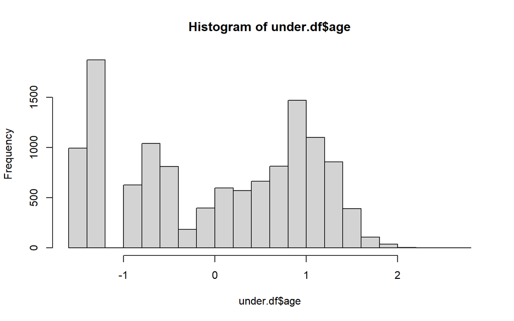

```r
hist(under.df$age)
```

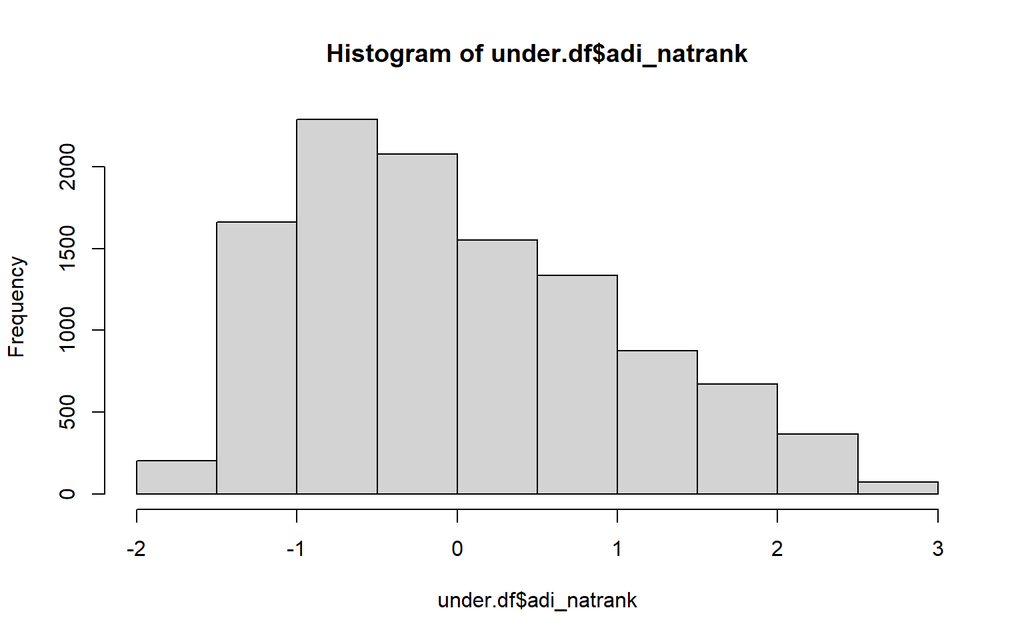

```r
hist(under.df$adi_natrank)
```

### EDA

#### predicted_race

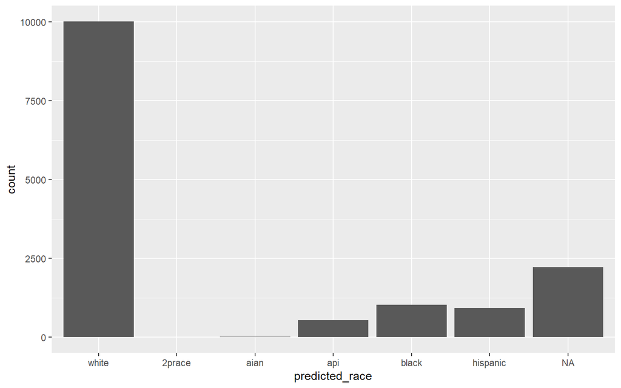

```r
ggplot(data = under.df) +
  geom_bar(mapping = aes(x = predicted_race))
```

```r
summary(under.df$predicted_race)
```

```
##    white   2prace     aian      api    black hispanic     NA's
##    10013        2       15      547     1035      928     2218
```

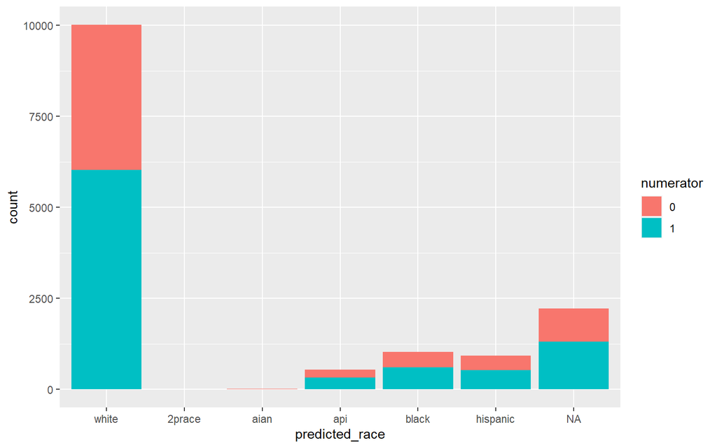

```r
ggplot(data = under.df) +
  geom_bar(mapping = aes(x = predicted_race, fill = numerator))
```

```r
prop.table(table(under.df$numerator, under.df$predicted_race),1)
```

```
##
##            white       2prace         aian          api        black
##   0 0.7884957501 0.0003953350 0.0015813402 0.0442775252 0.0857877051
##   1 0.8052399412 0.0000000000 0.0009357038 0.0431760460 0.0803368534
##
##         hispanic
##   0 0.0794623443
##   1 0.0703114557
```

```r
prop.table(table(under.df$predicted_race,under.df$numerator),1)
```

```
##
##                    0         1
##   white    0.3983821 0.6016179
##   2prace   1.0000000 0.0000000
##   aian     0.5333333 0.4666667
##   api      0.4095064 0.5904936
##   black    0.4193237 0.5806763
##   hispanic 0.4331897 0.5668103
```

#### gender

```r
summary(under.df$gender)
```

```
##  FEMALE    MALE UNKNOWN    NA's
##    7556    4982       2    2218
```

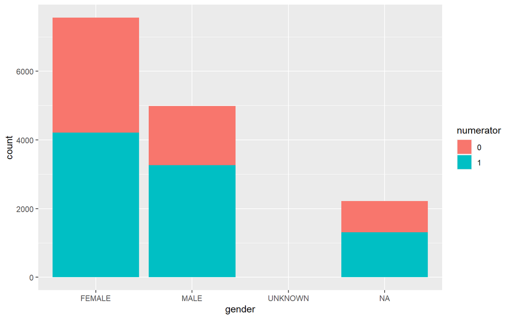

```r
ggplot(data = under.df) +
  geom_bar(mapping = aes(x = gender, fill = numerator))
```

```r
prop.table(table(under.df$numerator, under.df$gender),1)
```

```
##
##           FEMALE         MALE      UNKNOWN
##   0 0.6608025301 0.3391974699 0.0000000000
##   1 0.5631600053 0.4365726507 0.0002673439
```

#### age

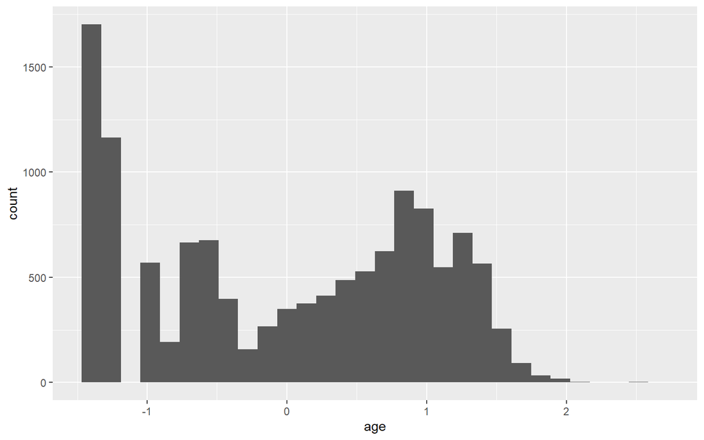

```r
ggplot(data=under.df, aes(x = age)) +
  geom_histogram()
```

```r
# number of NAs
sum(is.na(under.df$age))
```

```
## [1] 2218
```

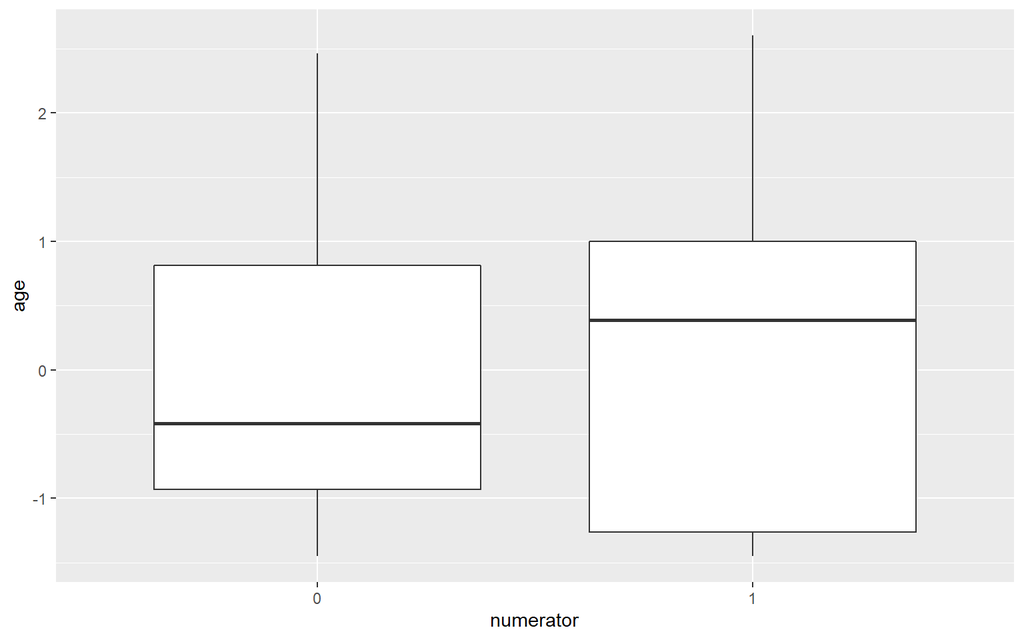

```r
ggplot(data=under.df, aes(x = numerator, y = age)) +
  geom_boxplot()
```

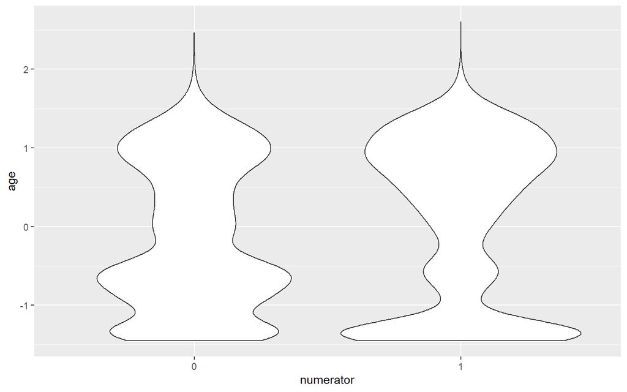

```r
ggplot(data=under.df, aes(x = numerator, y = age)) +
  geom_violin()
```

```r
age_summary <- under.df %>%
  group_by(numerator) %>%
  summarize(n = n(),
         mean = mean(age,na.rm=TRUE),
         median = median(age,na.rm=TRUE),
         sd = sd(age,na.rm=TRUE)
         )
age_summary
```

```
## # A tibble: 2 x 5
##   numerator     n    mean median    sd
##   <fct>     <int>   <dbl>  <dbl> <dbl>
## 1 0          5967 -0.120  -0.414 0.927
## 2 1          8791  0.0813  0.387 1.04
```

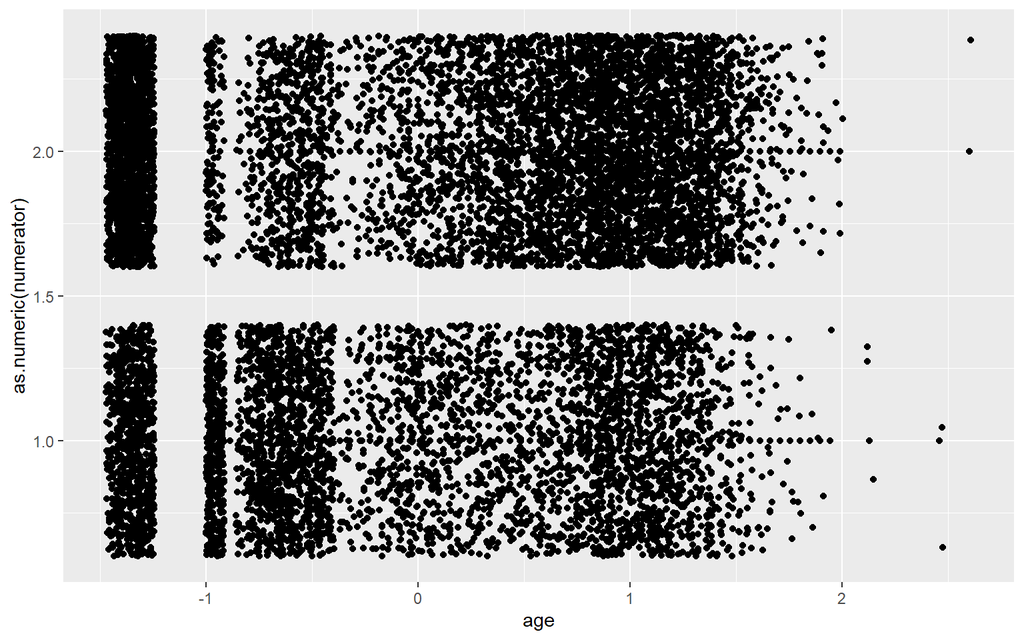

```r
ggplot(data = under.df, aes(x =age, y = as.numeric(numerator) )) +
  geom_point() +
  geom_jitter()
```